# Happy Customer

## Context:

We are one of the fastest growing startups in the logistics and delivery domain. We work with several partners and make on-demand delivery to our customers. During the COVID-19 pandemic, we are facing several different challenges and everyday we are trying to address these challenges.

We thrive on making our customers happy. As a growing startup, with a global expansion strategy we know that we need to make our customers happy and the only way to do that is to measure how happy each customer is. If we can predict what makes our customers happy or unhappy, we can then take necessary actions.

Getting feedback from customers is not easy either, but we do our best to get constant feedback from our customers. This is a crucial function to improve our operations across all levels.

We recently did a survey to a select customer cohort. You are presented with a subset of this data. We will be using the remaining data as a private test set.

## Objective:

Predict if a customer is happy or not based on the answers they give to questions asked.

## Data Description:

- Y = target attribute (Y) with values indicating 0 (unhappy) and 1 (happy) customers
- X1 = my order was delivered on time
- X2 = contents of my order was as I expected
- X3 = I ordered everything I wanted to order
- X4 = I paid a good price for my order
- X5 = I am satisfied with my courier
- X6 = the app makes ordering easy for me

Attributes X1 to X6 indicate the responses for each question and have values from 1 to 5 where the smaller number indicates less and the higher number indicates more towards the answer.

## Success Metrics:

Reach 73% accuracy score or above, or convince us why your solution is superior. We are definitely interested in every solution and insight you can provide us.

## Let's start by importing necessary libraries

```python
# this will help in making the Python code more structured automatically (good coding practice)
# %load_ext nb_black

import warnings
warnings.filterwarnings("ignore")

# Libraries to help with reading and manipulating data
import numpy as np
import pandas as pd

import os
os.environ['NUMEXPR_MAX_THREADS'] = '4'
os.environ['NUMEXPR_NUM_THREADS'] = '2'
import numexpr as ne

# Library to split data
from sklearn.model_selection import train_test_split

# libaries to help with data visualization
import matplotlib.pyplot as plt
import seaborn as sns

# Removes the limit for the number of displayed columns
pd.set_option("display.max_columns", None)
# Sets the limit for the number of displayed rows
pd.set_option("display.max_rows", 100)


# Libraries different ensemble classifiers
from sklearn.ensemble import (
    BaggingClassifier,
    RandomForestClassifier,
    AdaBoostClassifier,
    GradientBoostingClassifier,
    StackingClassifier,
)

from xgboost import XGBClassifier
from sklearn.tree import DecisionTreeClassifier

# Libraries to get different metric scores
from sklearn import metrics
from sklearn.metrics import (
    confusion_matrix,
    accuracy_score,
    precision_score,
    recall_score,
    f1_score,
)

# To tune different models
from sklearn.model_selection import GridSearchCV
```

## Import Dataset

```python
# copying data to another varaible to avoid any changes to original data
df = pd.read_csv("ACME-HappinessSurvey2020.csv")
```

```python
data = df.copy()
```

### View the first and last 5 rows of the dataset.

```python
data.head()
```

|  | Y | X1 | X2 | X3 | X4 | X5 | X6 |
| --- | --- | --- | --- | --- | --- | --- | --- |
| 0 | 0 | 3 | 3 | 3 | 4 | 2 | 4 |
| 1 | 0 | 3 | 2 | 3 | 5 | 4 | 3 |
| 2 | 1 | 5 | 3 | 3 | 3 | 3 | 5 |
| 3 | 0 | 5 | 4 | 3 | 3 | 3 | 5 |
| 4 | 0 | 5 | 4 | 3 | 3 | 3 | 5 |

```python
data.tail()
```

|  | Y | X1 | X2 | X3 | X4 | X5 | X6 |
| --- | --- | --- | --- | --- | --- | --- | --- |
| 121 | 1 | 5 | 2 | 3 | 4 | 4 | 3 |
| 122 | 1 | 5 | 2 | 3 | 4 | 2 | 5 |
| 123 | 1 | 5 | 3 | 3 | 4 | 4 | 5 |
| 124 | 0 | 4 | 3 | 3 | 4 | 4 | 5 |
| 125 | 0 | 5 | 3 | 2 | 5 | 5 | 5 |

```python
data.copy(deep=True)
```

|  | Y | X1 | X2 | X3 | X4 | X5 | X6 |
| --- | --- | --- | --- | --- | --- | --- | --- |
| 0 | 0 | 3 | 3 | 3 | 4 | 2 | 4 |
| 1 | 0 | 3 | 2 | 3 | 5 | 4 | 3 |
| 2 | 1 | 5 | 3 | 3 | 3 | 3 | 5 |
| 3 | 0 | 5 | 4 | 3 | 3 | 3 | 5 |
| 4 | 0 | 5 | 4 | 3 | 3 | 3 | 5 |
| ... | ... | ... | ... | ... | ... | ... | ... |
| 121 | 1 | 5 | 2 | 3 | 4 | 4 | 3 |
| 122 | 1 | 5 | 2 | 3 | 4 | 2 | 5 |
| 123 | 1 | 5 | 3 | 3 | 4 | 4 | 5 |
| 124 | 0 | 4 | 3 | 3 | 4 | 4 | 5 |
| 125 | 0 | 5 | 3 | 2 | 5 | 5 | 5 |

### Understand the shape of the dataset.

```python
data.shape
```

```
(126, 7)
```

- The dataset has 126 rows and 7 columns of data

### Check the data types of the columns for the dataset.

```python
data.info()
```

```
<class 'pandas.core.frame.DataFrame'>
RangeIndex: 126 entries, 0 to 125
Data columns (total 7 columns):
 #   Column  Non-Null Count  Dtype
---  ------  --------------  -----
 0   Y       126 non-null    int64
 1   X1      126 non-null    int64
 2   X2      126 non-null    int64
 3   X3      126 non-null    int64
 4   X4      126 non-null    int64
 5   X5      126 non-null    int64
 6   X6      126 non-null    int64
dtypes: int64(7)
memory usage: 7.0 KB
```

### Insights:

- Most of the data-types are **int64**.

### Let's check the duplicate data. And if any, we should remove it.

```python
# checking for duplicate values
data[data.duplicated()].count()
```

```
Y     16
X1    16
X2    16
X3    16
X4    16
X5    16
X6    16
dtype: int64
```

- There are duplicate values in the dataset

```python
data.drop_duplicates(inplace=True)
```

```python
duplicatedata = data.duplicated().sum()
print(duplicatedata)
```

```
0
```

```python
data.shape
```

```
(110, 7)
```

### Check for missing values

```python
data.isnull().values.any()
```

```
False
```

- There are no missing values in the data.

### Summary of the dataset

```python
data.describe().T
```

|  | count | mean | std | min | 25% | 50% | 75% | max |
| --- | --- | --- | --- | --- | --- | --- | --- | --- |
| Y | 110.0 | 0.509091 | 0.502205 | 0.0 | 0.0 | 1.0 | 1.0 | 1.0 |
| X1 | 110.0 | 4.309091 | 0.809864 | 1.0 | 4.0 | 4.5 | 5.0 | 5.0 |
| X2 | 110.0 | 2.536364 | 1.106091 | 1.0 | 2.0 | 3.0 | 3.0 | 5.0 |
| X3 | 110.0 | 3.272727 | 1.012845 | 1.0 | 3.0 | 3.0 | 4.0 | 5.0 |
| X4 | 110.0 | 3.736364 | 0.895219 | 1.0 | 3.0 | 4.0 | 4.0 | 5.0 |
| X5 | 110.0 | 3.590909 | 1.190909 | 1.0 | 3.0 | 4.0 | 4.0 | 5.0 |
| X6 | 110.0 | 4.209091 | 0.836062 | 1.0 | 4.0 | 4.0 | 5.0 | 5.0 |

## Exploratory Data Analysis(EDA)

### Univariate analysis

```python
# function to plot a boxplot and a histogram along the same scale.


def histogram_boxplot(data, feature, figsize=(12, 7), kde=False, bins=None):
    """
    Boxplot and histogram combined

    data: dataframe
    feature: dataframe column
    figsize: size of figure (default (12,7))
    kde: whether to the show density curve (default False)
    bins: number of bins for histogram (default None)
    """
    f2, (ax_box2, ax_hist2) = plt.subplots(
        nrows=2,  # Number of rows of the subplot grid= 2
        sharex=True,  # x-axis will be shared among all subplots
        gridspec_kw={"height_ratios": (0.25, 0.75)},
        figsize=figsize,
    )  # creating the 2 subplots
    sns.boxplot(
        data=data, x=feature, ax=ax_box2, showmeans=True, color="violet"
    )  # boxplot will be created and a star will indicate the mean value of the column
    sns.histplot(
        data=data, x=feature, kde=kde, ax=ax_hist2, bins=bins, palette="winter"
    ) if bins else sns.histplot(
        data=data, x=feature, kde=kde, ax=ax_hist2
    )  # For histogram
    ax_hist2.axvline(
        data[feature].mean(), color="green", linestyle="--"
    )  # Add mean to the histogram
    ax_hist2.axvline(
        data[feature].median(), color="black", linestyle="-"
    )  # Add median to the histogram
```

```python
def labeled_barplot(data, feature, perc=False, n=None):
    """
    Barplot with percentage at the top

    data: dataframe
    feature: dataframe column
    perc: whether to display percentages instead of count (default is False)
    n: displays the top n category levels (default is None, i.e., display all levels)
    """

    total = len(data[feature])  # length of the column
    count = data[feature].nunique()
    if n is None:
        plt.figure(figsize=(count + 1, 5))
    else:
        plt.figure(figsize=(n + 1, 5))

    plt.xticks(rotation=90, fontsize=15)
    ax = sns.countplot(
        data=data,
        x=feature,
        palette="Paired",
        order=data[feature].value_counts().index[:n].sort_values(),
    )

    for p in ax.patches:
        if perc == True:
            label = "{:.1f}%".format(
                100 * p.get_height() / total
            )  # percentage of each class of the category
        else:
            label = p.get_height()  # count of each level of the category

        x = p.get_x() + p.get_width() / 2  # width of the plot
        y = p.get_height()  # height of the plot

        ax.annotate(
            label,
            (x, y),
            ha="center",
            va="center",
            size=12,
            xytext=(0, 5),
            textcoords="offset points",
        )  # annotate the percentage

    plt.show()  # show the plot
```

```python
data.columns
```

```
Index(['Y', 'X1', 'X2', 'X3', 'X4', 'X5', 'X6'], dtype='object')
```

### Observation on Target attribute

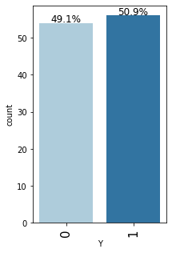

```python
labeled_barplot(data, "Y", perc=True)
```

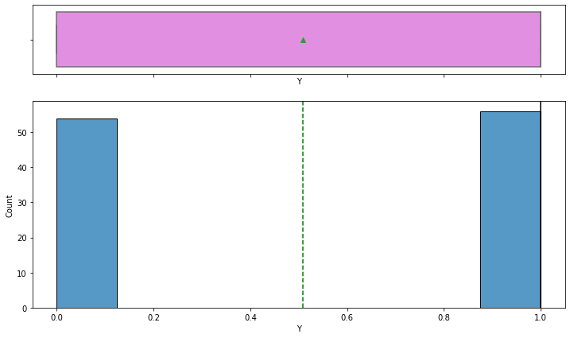

```python
histogram_boxplot(data, "Y")
```

```python
data["Y"].value_counts()
```

```
1    56
0    54
Name: Y, dtype: int64
```

- 49.1% of Customers are indicating unhappy.
- 50.9% of Customers are indicating happy.

### Observation on customers X1 - my order was delivered on time

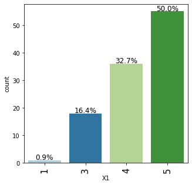

```python
labeled_barplot(data, "X1", perc=True)
```

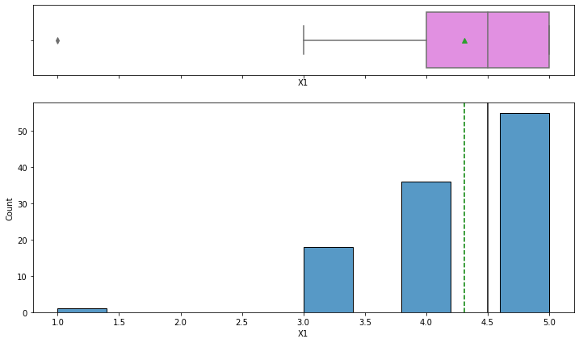

```python
histogram_boxplot(data, "X1")
```

```python
data["X1"].value_counts()
```

```
5    55
4    36
3    18
1     1
Name: X1, dtype: int64
```

- 50% of customers were rating 5 as the order delivered ontime.
- 32.7% of customers were rating 4 as the order delivered ontime.

### Observation on customers X2 - my order was as I expected

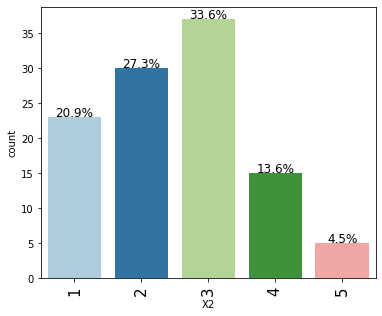

```python
labeled_barplot(data, "X2", perc=True)
```

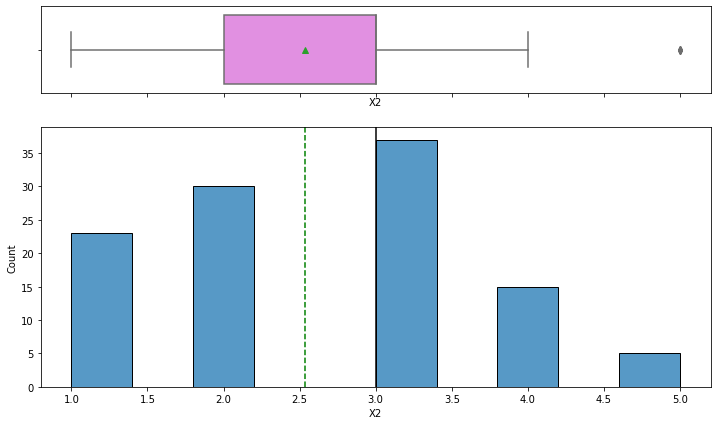

```python
histogram_boxplot(data, "X2")
```

```python
data["X2"].value_counts()
```

```
3    37
2    30
1    23
4    15
5     5
Name: X2, dtype: int64
```

- 4.5% Customers were rating contents of my order was as I expected.

### Observation on customers X3 - I ordered everything I wanted to order

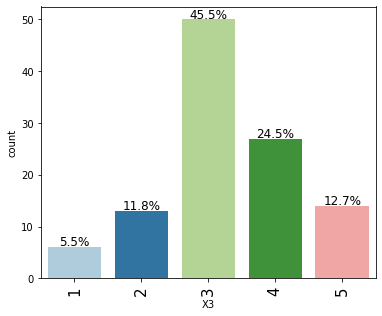

```python
labeled_barplot(data, "X3", perc=True)
```

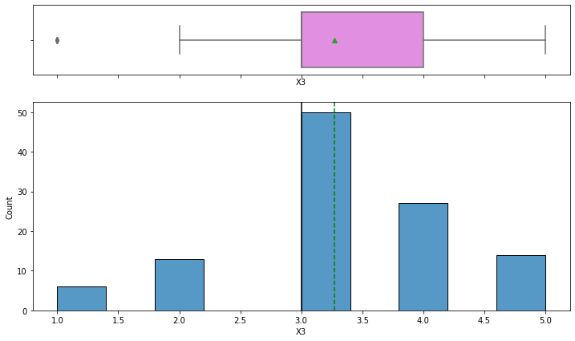

```python
histogram_boxplot(data, "X3")
```

```python
data["X3"].value_counts()
```

```
3    50
4    27
5    14
2    13
1     6
Name: X3, dtype: int64
```

*12.7% Customers ordered everything they wanted to order.

### Observation on customers X4 - I paid a good price for my order

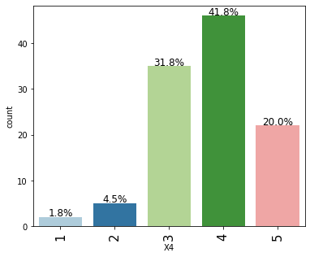

```python
labeled_barplot(data, "X4", perc=True)
```

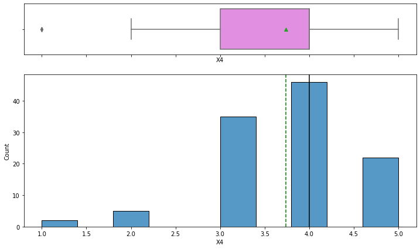

```python
histogram_boxplot(data, "X4")
```

```python
data["X4"].value_counts()
```

```
4    46
3    35
5    22
2     5
1     2
Name: X4, dtype: int64
```

- 20% Customers are satisified for the price they paid for their order.
- 22 customers are satisified for the price they paid for their order.

### Observation on customers X5 - I am satisfied with my courier

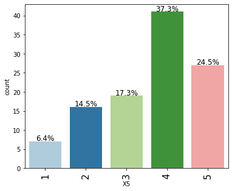

```python
labeled_barplot(data, "X5", perc=True)
```

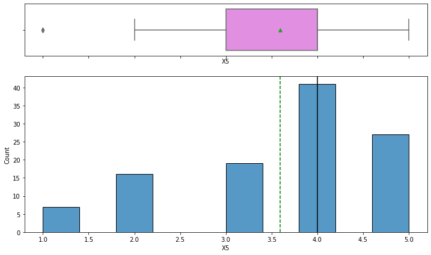

```python
histogram_boxplot(data, "X5")
```

```python
data["X5"].value_counts()
```

```
4    41
5    27
3    19
2    16
1     7
Name: X5, dtype: int64
```

- 24.5% Customers are satified with their courier.
- 27 Customers are satified with the courier they received.

### Observation on customers X6 - the app makes ordering easy for me

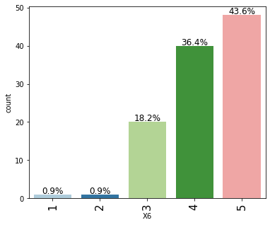

```python
labeled_barplot(data, "X6", perc=True)
```

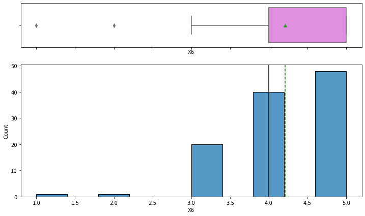

```python
histogram_boxplot(data, "X6")
```

```python
data["X6"].value_counts()
```

```
5    48
4    40
3    20
1     1
2     1
Name: X6, dtype: int64
```

- 43.6% Customers says the app makes ordering easy for me
- 48 Customers given the rating 5 says the app makes ordering easy for me

## Bivariate Analysis

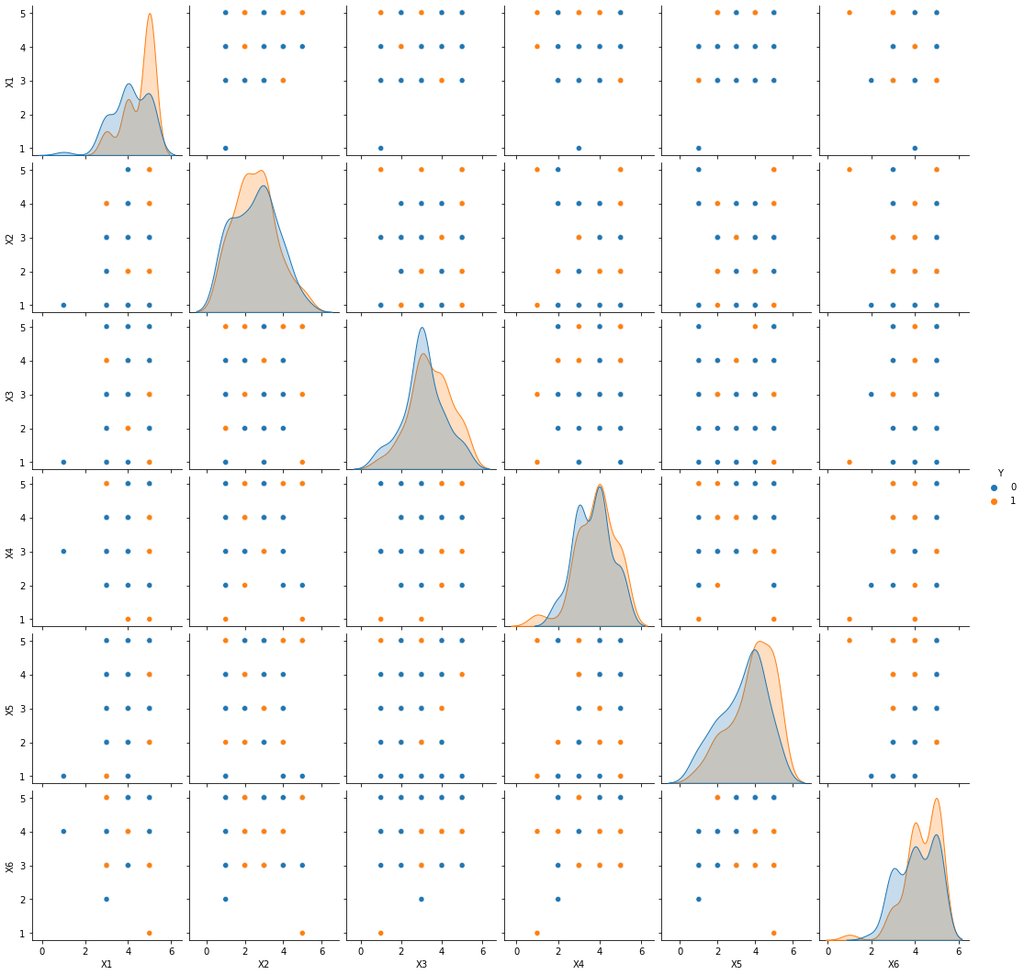

```python
sns.pairplot(data, hue="Y")
plt.show()
```

- Let's explore this further with the help of other plots.

### How are the different variables correlated with each other?

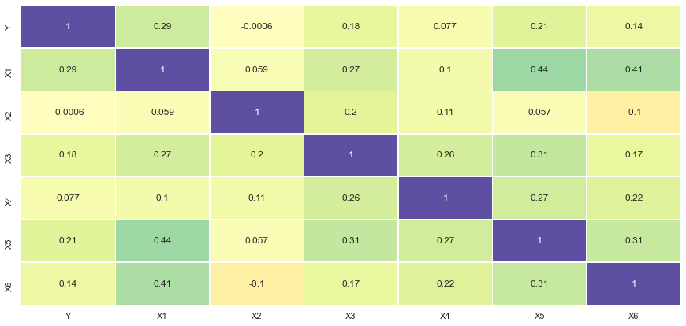

```python
sns.set(rc={'figure.figsize':(15,7)})
sns.heatmap(data.corr(),
            annot=True,
            linewidths=.5,
            center=0,
            cbar=False,
            cmap="Spectral")
plt.show()
```

- The high correlation observed between X1 - My order delivered on time and X5 - I am satisfied with my courier, X6 - the app makes ordering easy for me.

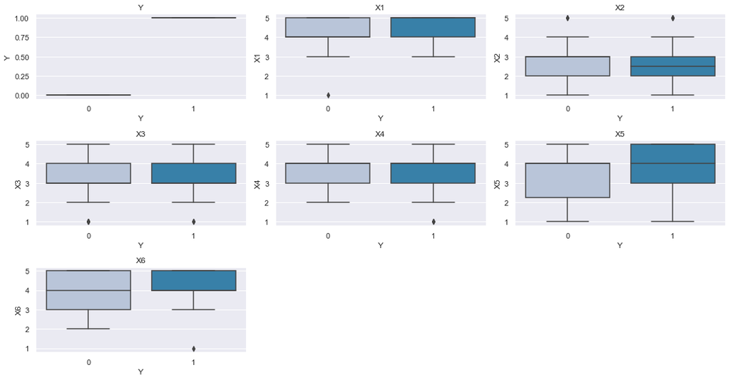

```python
cols = data[["Y", "X1", "X2", "X3", "X4", "X5", "X6",]].columns.tolist()
plt.figure(figsize=(15, 10))

for i, variable in enumerate(cols):
    plt.subplot(4, 3, i + 1)
    sns.boxplot(data["Y"], data[variable], palette="PuBu")
    plt.tight_layout()
    plt.title(variable)
plt.show()
```

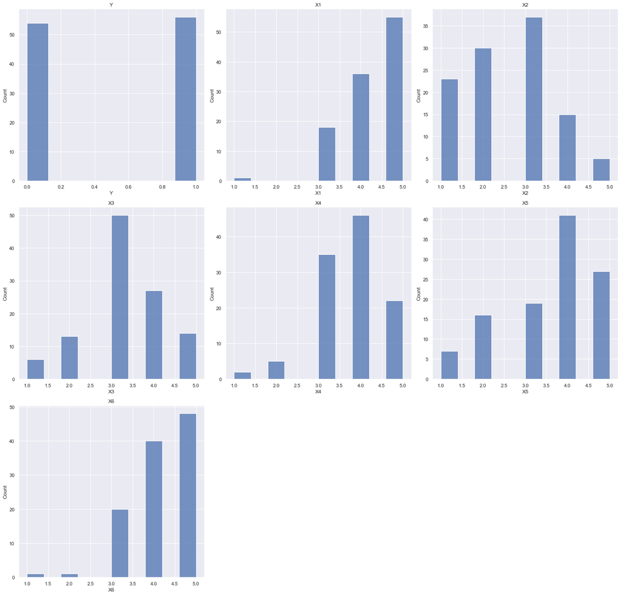

```python
cols = data[["Y", "X1", "X2", "X3", "X4", "X5", "X6",]].columns.tolist()
plt.figure(figsize=(20, 25))

for i, variable in enumerate(cols):
    plt.subplot(4, 3, i + 1)
    sns.histplot(data[variable],)
    plt.tight_layout()
    plt.title(variable)
plt.show()
```

```python
### function to plot distributions wrt target


def distribution_plot_wrt_target(data, predictor, target):

    fig, axs = plt.subplots(2, 2, figsize=(12, 10))

    target_uniq = data[target].unique()

    axs[0, 0].set_title("Distribution of target for target=" + str(target_uniq[0]))
    sns.histplot(
        data=data[data[target] == target_uniq[0]],
        x=predictor,
        kde=True,
        ax=axs[0, 0],
        color="teal",
        stat="density",
    )

    axs[0, 1].set_title("Distribution of target for target=" + str(target_uniq[1]))
    sns.histplot(
        data=data[data[target] == target_uniq[1]],
        x=predictor,
        kde=True,
        ax=axs[0, 1],
        color="orange",
        stat="density",
    )

    axs[1, 0].set_title("Boxplot w.r.t target")
    sns.boxplot(data=data, x=target, y=predictor, ax=axs[1, 0], palette="gist_rainbow")

    axs[1, 1].set_title("Boxplot (without outliers) w.r.t target")
    sns.boxplot(
        data=data,
        x=target,
        y=predictor,
        ax=axs[1, 1],
        showfliers=False,
        palette="gist_rainbow",
    )

    plt.tight_layout()
    plt.show()
```

```python
def stacked_barplot(data, predictor, target):
    """
    Print the category counts and plot a stacked bar chart

    data: dataframe
    predictor: independent variable
    target: target variable
    """
    count = data[predictor].nunique()
    sorter = data[target].value_counts().index[-1]
    tab1 = pd.crosstab(data[predictor], data[target], margins=True).sort_values(
        by=sorter, ascending=False
    )
    print(tab1)
    print("-" * 120)
    tab = pd.crosstab(data[predictor], data[target], normalize="index").sort_values(
        by=sorter, ascending=False
    )
    tab.plot(kind="bar", stacked=True, figsize=(count + 5, 5))
    plt.legend(
        loc="lower left", frameon=False,
    )
    plt.legend(loc="upper left", bbox_to_anchor=(1, 1))
    plt.show()
```

### Y Vs X1, X5, X6

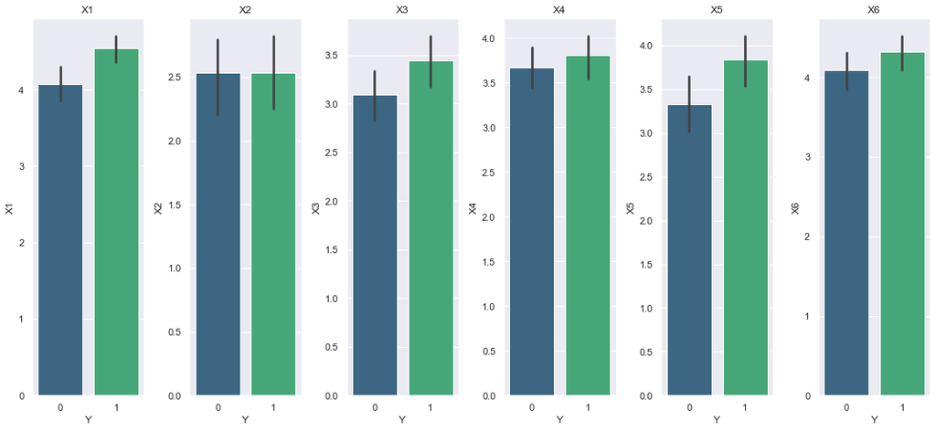

```python
cols = data[["X1", "X2", "X3", "X4", "X5", "X6"]].columns.tolist()
plt.figure(figsize=(15, 7))

for i, variable in enumerate(cols):
    plt.subplot(1, 6, i + 1)
    sns.barplot(data["Y"], data[variable], palette="viridis")
    plt.tight_layout()
    plt.title(variable)
plt.show()
```

- X1 - My order delivered on time.
- X5 - I am satisfied with my courier.
- X6 - the app makes ordering easy for me.
- These 3 customer feedback had the highest distributtion of ratings above 3 out of 5.

```python
data.groupby("Y")["X1"].mean()
```

```
Y
0    4.074074
1    4.535714
Name: X1, dtype: float64
```

```python
data.groupby("Y")["X5"].mean()
```

```
Y
0    3.333333
1    3.839286
Name: X5, dtype: float64
```

```python
data.groupby("Y")["X6"].mean()
```

```
Y
0    4.092593
1    4.321429
Name: X6, dtype: float64
```

```
Y     0   1  All
X1
All  54  56  110
4    22  14   36
5    19  36   55
3    12   6   18
1     1   0    1
------------------------------------------------------------------------------------------------------------------------
```

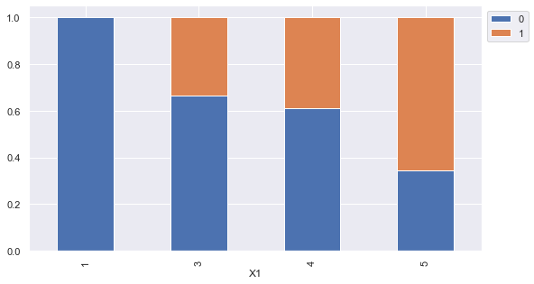

```python
stacked_barplot(data, "X1", "Y")
```

```
Y     0   1  All
X5
All  54  56  110
4    21  20   41
3    11   8   19
2     9   7   16
5     8  19   27
1     5   2    7
------------------------------------------------------------------------------------------------------------------------
```

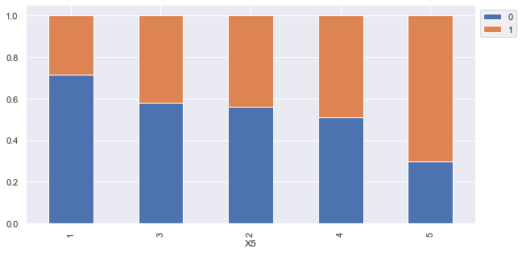

```python
stacked_barplot(data, "X5", "Y")
```

```
Y     0   1  All
X6
All  54  56  110
5    21  27   48
4    18  22   40
3    14   6   20
2     1   0    1
1     0   1    1
------------------------------------------------------------------------------------------------------------------------
```

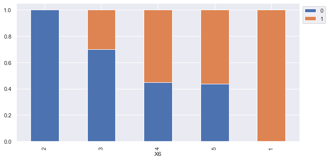

```python
stacked_barplot(data, "X6", "Y")
```

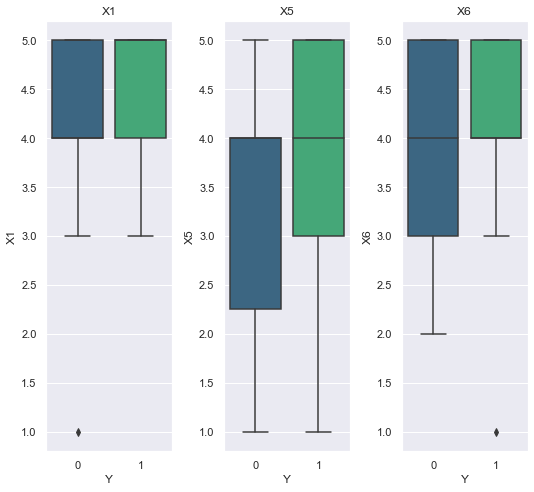

```python
cols = data[["X1", "X5", "X6"]].columns.tolist()
plt.figure(figsize=(15, 7))

for i, variable in enumerate(cols):
    plt.subplot(1, 6, i + 1)
    sns.boxplot(data["Y"], data[variable], palette="viridis")
    plt.tight_layout()
    plt.title(variable)
plt.show()
```

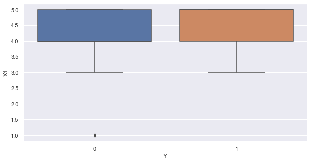

```python
plt.figure(figsize=(10, 5))
sns.boxplot(data=data, x="Y", y="X1")
plt.show()
```

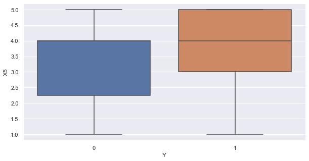

```python
plt.figure(figsize=(10, 5))
sns.boxplot(data=data, x="Y", y="X5")
plt.show()
```

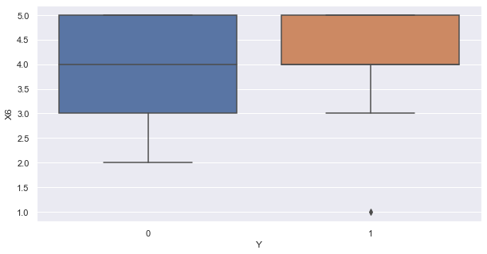

```python
plt.figure(figsize=(10, 5))
sns.boxplot(data=data, x="Y", y="X6")
plt.show()
```

## Data Preprocessing

### Outlier Detection

- Let's look at outliers in every numerical column

```python
data.info()
```

```
<class 'pandas.core.frame.DataFrame'>
Int64Index: 110 entries, 0 to 125
Data columns (total 7 columns):
 #   Column  Non-Null Count  Dtype
---  ------  --------------  -----
 0   Y       110 non-null    int64
 1   X1      110 non-null    int64
 2   X2      110 non-null    int64
 3   X3      110 non-null    int64
 4   X4      110 non-null    int64
 5   X5      110 non-null    int64
 6   X6      110 non-null    int64
dtypes: int64(7)
memory usage: 10.9 KB
```

```python
data1 = data.copy()
```

```python
data1.columns
```

```
Index(['Y', 'X1', 'X2', 'X3', 'X4', 'X5', 'X6'], dtype='object')
```

```python
data1.info()
```

```
<class 'pandas.core.frame.DataFrame'>
Int64Index: 110 entries, 0 to 125
Data columns (total 7 columns):
 #   Column  Non-Null Count  Dtype
---  ------  --------------  -----
 0   Y       110 non-null    int64
 1   X1      110 non-null    int64
 2   X2      110 non-null    int64
 3   X3      110 non-null    int64
 4   X4      110 non-null    int64
 5   X5      110 non-null    int64
 6   X6      110 non-null    int64
dtypes: int64(7)
memory usage: 10.9 KB
```

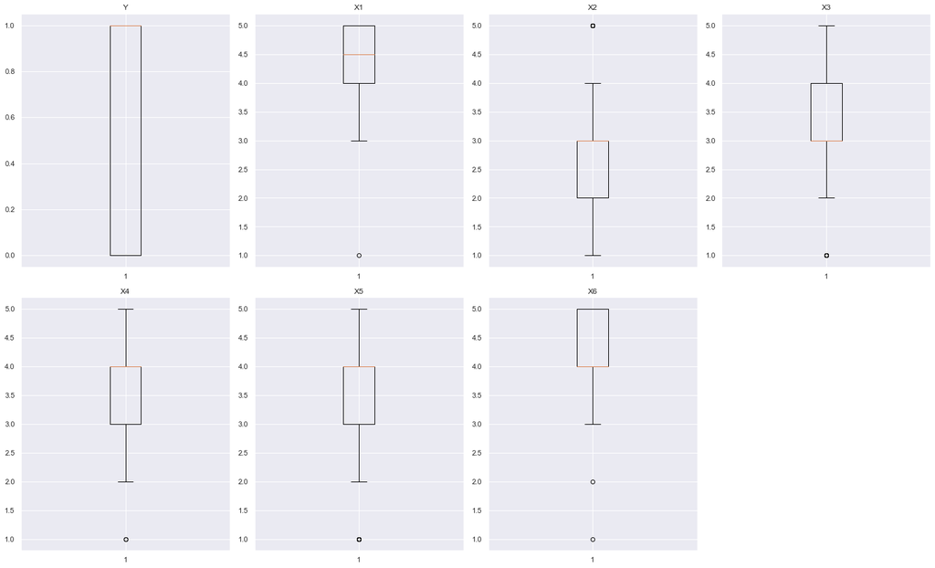

```python
# outlier detection using boxplot
numeric_columns = data1.select_dtypes(include=np.number).columns.tolist()

plt.figure(figsize=(20, 30))

for i, variable in enumerate(numeric_columns):
    plt.subplot(5, 4, i + 1)
    plt.boxplot(data1[variable], whis=1.5)
    plt.tight_layout()
    plt.title(variable)

plt.show()
```

#### Observations

We will treat these outliers as these might adversely affect the predictive power of linear model. However, in real life, these outliers may be due to non-linear pattern in the data or can be important information.

Sometimes outliers in the independent variable can adversely impact the linear model. This can be checked by building the model with and without outliers and comparing the model performances.

### Outlier Treatment

- Let's treat outliers in the data by flooring and capping.

```python
def treat_outliers(loan1, col):
    """
    treats outliers in a variable
    col: str, name of the numerical variable
    df: dataframe
    col: name of the column
    """
    Q1 = data1[col].quantile(0.25)  # 25th quantile
    Q3 = data1[col].quantile(0.75)  # 75th quantile
    IQR = Q3 - Q1
    Lower_Whisker = Q1 - 1.5 * IQR
    Upper_Whisker = Q3 + 1.5 * IQR

    # all the values smaller than Lower_Whisker will be assigned the value of Lower_Whisker
    # all the values greater than Upper_Whisker will be assigned the value of Upper_Whisker
    loan1[col] = np.clip(data1[col], Lower_Whisker, Upper_Whisker)

    return data1


def treat_outliers_all(data1, col_list):
    """
    treat outlier in all numerical variables
    col_list: list of numerical variables
    df: data frame
    """
    for c in col_list:
        data1 = treat_outliers(data1, c)

    return data1
```

```python
# treating the outliers
numerical_col = data1.select_dtypes(include=np.number).columns.tolist()
data1 = treat_outliers_all(data1, numerical_col)
```

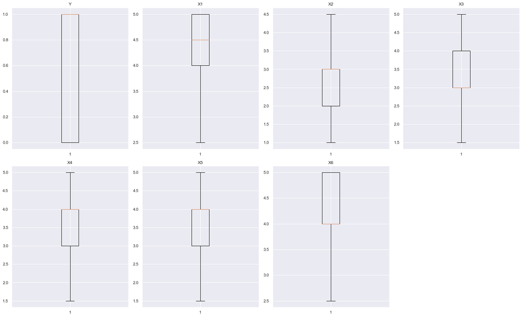

```python
# let's look at the boxplots to see if the outliers have been treated or not
plt.figure(figsize=(20, 30))
# dropping release_year as it is a temporal variable

for i, variable in enumerate(numeric_columns):
    plt.subplot(5, 4, i + 1)
    plt.boxplot(data1[variable], whis=1.5)
    plt.tight_layout()
    plt.title(variable)

plt.show()
```

### Model evaluation criterion

### Model can make wrong predictions as:

1. Predicting a customer will be happy based on the answers to the questions they asked but in reality the customer is not happy.
2. Predicting a customer will not be happy based on the answers to the questions they askebd but in reality the customer is happy.

### Which case is more important?

- Both the cases are important as:
- If we can predict what makes our customers happy or unhappy, we can then take necessary actions.

### How to reduce the losses?

- "Accuracy" can be used a the metric for evaluation of the model, greater the F1 score higher are the chances of minimizing False Negatives and False Positives.
- We will use balanced class weights so that model focuses equally on both classes.
- "Recall" should be maximized, the greater the recall higher the chances of minimizing the false negatives.
- Company wants to reach 73% accuracy score or above,Accuracy to be maximized, greater the Accuracy higher the chances of minimizing false negatives. Hence, the focus should be on increasing Accuracy or minimizing the false negatives or in other words identifying the true positives(i.e. Class 1) so that the company can Reach 73% accuracy score or above, or convince us why your solution is superior. We are definitely interested in every solution and insight you can provide us.

### Addition of New variables

```python
# dropping PageValues
data1 = data1.drop(["Y"], axis=1)
```

```python
replaceStruct = {
    "X1": {"value1": 1, "value2": 2, "value3": 3, "value4": 4, "value5": 5,},
    "X2": {"value1": 1, "value2": 2, "value3": 3, "value4": 4, "value5": 5,},
    "X3": {"value1": 1, "value2": 2, "value3": 3, "value4": 4, "value5": 5,},
    "X4": {"value1": 1, "value2": 2, "value3": 3, "value4": 4, "value5": 5,},
    "X5": {"value1": 1, "value2": 2, "value3": 3, "value4": 4, "value5": 5,},
    "X6": {"value1": 1, "value2": 2, "value3": 3, "value4": 4, "value5": 5,},
}
oneHotCols = ["X1", "X2", "X3", "X4", "X5", "X6"]
```

```python
data1 = data1.replace(replaceStruct)
data1 = pd.get_dummies(data, columns=oneHotCols)
data1.head(15)
```

|  | Y | X1_1 | X1_3 | X1_4 | X1_5 | X2_1 | X2_2 | X2_3 | X2_4 | X2_5 | X3_1 | X3_2 | X3_3 | X3_4 | X3_5 | X4_1 | X4_2 | X4_3 | X4_4 | X4_5 | X5_1 | X5_2 | X5_3 | X5_4 | X5_5 | X6_1 | X6_2 | X6_3 | X6_4 | … |
| --- | --- | --- | --- | --- | --- | --- | --- | --- | --- | --- | --- | --- | --- | --- | --- | --- | --- | --- | --- | --- | --- | --- | --- | --- | --- | --- | --- | --- | --- | --- |
| 0 | 0 | 0 | 1 | 0 | 0 | 0 | 0 | 1 | 0 | 0 | 0 | 0 | 1 | 0 | 0 | 0 | 0 | 0 | 1 | 0 | 0 | 1 | 0 | 0 | 0 | 0 | 0 | 0 | 1 | … |
| 1 | 0 | 0 | 1 | 0 | 0 | 0 | 1 | 0 | 0 | 0 | 0 | 0 | 1 | 0 | 0 | 0 | 0 | 0 | 0 | 1 | 0 | 0 | 0 | 1 | 0 | 0 | 0 | 1 | 0 | … |
| 2 | 1 | 0 | 0 | 0 | 1 | 0 | 0 | 1 | 0 | 0 | 0 | 0 | 1 | 0 | 0 | 0 | 0 | 1 | 0 | 0 | 0 | 0 | 1 | 0 | 0 | 0 | 0 | 0 | 0 | … |
| 3 | 0 | 0 | 0 | 0 | 1 | 0 | 0 | 0 | 1 | 0 | 0 | 0 | 1 | 0 | 0 | 0 | 0 | 1 | 0 | 0 | 0 | 0 | 1 | 0 | 0 | 0 | 0 | 0 | 0 | … |
| 5 | 1 | 0 | 0 | 0 | 1 | 0 | 0 | 0 | 0 | 1 | 0 | 0 | 1 | 0 | 0 | 0 | 0 | 0 | 0 | 1 | 0 | 0 | 0 | 0 | 1 | 0 | 0 | 0 | 0 | … |
| ... | ... | ... | ... | ... | ... | ... | ... | ... | ... | ... | ... | ... | ... | ... | ... | ... | ... | ... | ... | ... | ... | ... | ... | ... | ... | ... | ... | ... | ... | … |
| 11 | 0 | 0 | 0 | 1 | 0 | 0 | 0 | 0 | 1 | 0 | 0 | 0 | 1 | 0 | 0 | 0 | 0 | 0 | 1 | 0 | 0 | 0 | 0 | 1 | 0 | 0 | 0 | 0 | 1 | … |
| 12 | 1 | 0 | 0 | 0 | 1 | 0 | 1 | 0 | 0 | 0 | 0 | 0 | 0 | 1 | 0 | 0 | 0 | 0 | 0 | 1 | 0 | 0 | 0 | 0 | 1 | 0 | 0 | 0 | 0 | … |
| 13 | 0 | 0 | 0 | 1 | 0 | 0 | 1 | 0 | 0 | 0 | 0 | 0 | 0 | 1 | 0 | 0 | 0 | 0 | 0 | 1 | 0 | 0 | 0 | 1 | 0 | 0 | 0 | 1 | 0 | … |
| 14 | 0 | 0 | 0 | 1 | 0 | 1 | 0 | 0 | 0 | 0 | 0 | 0 | 1 | 0 | 0 | 0 | 0 | 1 | 0 | 0 | 0 | 0 | 0 | 1 | 0 | 0 | 0 | 1 | 0 | … |
| 15 | 1 | 0 | 1 | 0 | 0 | 0 | 1 | 0 | 0 | 0 | 0 | 0 | 0 | 1 | 0 | 0 | 0 | 1 | 0 | 0 | 0 | 0 | 0 | 1 | 0 | 0 | 0 | 0 | 1 | … |

```python
data1.info()
```

```
<class 'pandas.core.frame.DataFrame'>
Int64Index: 110 entries, 0 to 125
Data columns (total 30 columns):
 #   Column  Non-Null Count  Dtype
---  ------  --------------  -----
 0   Y       110 non-null    int64
 1   X1_1    110 non-null    uint8
 2   X1_3    110 non-null    uint8
 3   X1_4    110 non-null    uint8
 4   X1_5    110 non-null    uint8
 5   X2_1    110 non-null    uint8
 6   X2_2    110 non-null    uint8
 7   X2_3    110 non-null    uint8
 8   X2_4    110 non-null    uint8
 9   X2_5    110 non-null    uint8
```

[output cut: 22 more lines]

```python
data1.shape
```

```
(110, 30)
```

```python
x = data1.drop(["Y"], axis=1)
y = data1["Y"]
```

```python
# encoding the categorical variables
x = pd.get_dummies(x, drop_first=True)
x.head()
```

|  | X1_1 | X1_3 | X1_4 | X1_5 | X2_1 | X2_2 | X2_3 | X2_4 | X2_5 | X3_1 | X3_2 | X3_3 | X3_4 | X3_5 | X4_1 | X4_2 | X4_3 | X4_4 | X4_5 | X5_1 | X5_2 | X5_3 | X5_4 | X5_5 | X6_1 | X6_2 | X6_3 | X6_4 | X6_5 |
| --- | --- | --- | --- | --- | --- | --- | --- | --- | --- | --- | --- | --- | --- | --- | --- | --- | --- | --- | --- | --- | --- | --- | --- | --- | --- | --- | --- | --- | --- |
| 0 | 0 | 1 | 0 | 0 | 0 | 0 | 1 | 0 | 0 | 0 | 0 | 1 | 0 | 0 | 0 | 0 | 0 | 1 | 0 | 0 | 1 | 0 | 0 | 0 | 0 | 0 | 0 | 1 | 0 |
| 1 | 0 | 1 | 0 | 0 | 0 | 1 | 0 | 0 | 0 | 0 | 0 | 1 | 0 | 0 | 0 | 0 | 0 | 0 | 1 | 0 | 0 | 0 | 1 | 0 | 0 | 0 | 1 | 0 | 0 |
| 2 | 0 | 0 | 0 | 1 | 0 | 0 | 1 | 0 | 0 | 0 | 0 | 1 | 0 | 0 | 0 | 0 | 1 | 0 | 0 | 0 | 0 | 1 | 0 | 0 | 0 | 0 | 0 | 0 | 1 |
| 3 | 0 | 0 | 0 | 1 | 0 | 0 | 0 | 1 | 0 | 0 | 0 | 1 | 0 | 0 | 0 | 0 | 1 | 0 | 0 | 0 | 0 | 1 | 0 | 0 | 0 | 0 | 0 | 0 | 1 |
| 5 | 0 | 0 | 0 | 1 | 0 | 0 | 0 | 0 | 1 | 0 | 0 | 1 | 0 | 0 | 0 | 0 | 0 | 0 | 1 | 0 | 0 | 0 | 0 | 1 | 0 | 0 | 0 | 0 | 1 |

```python
# Splitting data into training, validation and test set:
# first we split data into 2 parts, say temporary and test

X_temp, X_test, y_temp, y_test = train_test_split(
    x, y, test_size=0.2, random_state=1, stratify=y
)

# then we split the temporary set into train and validation

X_train, X_val, y_train, y_val = train_test_split(
    X_temp, y_temp, test_size=0.25, random_state=1, stratify=y_temp
)
print(X_train.shape, X_val.shape, X_test.shape)
```

```
(66, 29) (22, 29) (22, 29)
```

```python
print("Shape of Training set : ", X_train.shape)
print("Shape of test set : ", X_test.shape)
print("Percentage of classes in training set:")
print(y_train.value_counts(normalize=True))
print("Percentage of classes in test set:")
print(y_test.value_counts(normalize=True))
```

```
Shape of Training set :  (66, 29)
Shape of test set :  (22, 29)
Percentage of classes in training set:
1    0.515152
0    0.484848
Name: Y, dtype: float64
Percentage of classes in test set:
0    0.5
1    0.5
Name: Y, dtype: float64
```

```python
# defining a function to compute different metrics to check performance of a classification model built using sklearn


def model_performance_classification_sklearn(model, predictors, target):
    """
    Function to compute different metrics to check classification model performance

    model: classifier
    predictors: independent variables
    target: dependent variable
    """

    # predicting using the independent variables
    pred = model.predict(predictors)

    acc = accuracy_score(target, pred)  # to compute Accuracy
    recall = recall_score(target, pred)  # to compute Recall
    precision = precision_score(target, pred)  # to compute Precision
    f1 = f1_score(target, pred)  # to compute F1-score

    # creating a dataframe of metrics
    df_perf = pd.DataFrame(
        {"Accuracy": acc, "Recall": recall, "Precision": precision, "F1": f1,},
        index=[0],
    )

    return df_perf
```

```python
def confusion_matrix_sklearn(model, predictors, target):
    """
    To plot the confusion_matrix with percentages

    model: classifier
    predictors: independent variables
    target: dependent variable
    """
    y_pred = model.predict(predictors)
    cm = confusion_matrix(target, y_pred)
    labels = np.asarray(
        [
            ["{0:0.0f}".format(item) + "\n{0:.2%}".format(item / cm.flatten().sum())]
            for item in cm.flatten()
        ]
    ).reshape(2, 2)

    plt.figure(figsize=(6, 4))
    sns.heatmap(cm, annot=labels, fmt="")
    plt.ylabel("True label")
    plt.xlabel("Predicted label")
```

### Decision Tree Model

```python
model = DecisionTreeClassifier(random_state=1)
model.fit(X_train, y_train)
```

```
DecisionTreeClassifier(random_state=1)
```

#### Checking model performance on training set

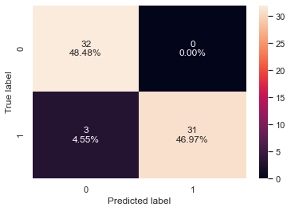

```python
confusion_matrix_sklearn(model, X_train, y_train)
```

```python
decision_tree_perf_train = model_performance_classification_sklearn(
    model, X_train, y_train
)
decision_tree_perf_train
```

|  | Accuracy | Recall | Precision | F1 |
| --- | --- | --- | --- | --- |
| 0 | 0.954545 | 0.911765 | 1.0 | 0.953846 |

#### Checking model performance on test set

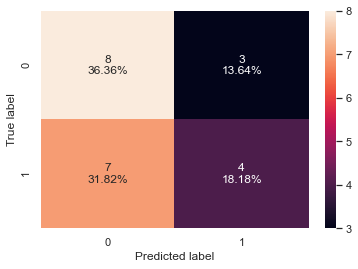

```python
confusion_matrix_sklearn(model, X_test, y_test)
```

```python
decision_tree_perf_test = model_performance_classification_sklearn(
    model, X_test, y_test
)
decision_tree_perf_test
```

|  | Accuracy | Recall | Precision | F1 |
| --- | --- | --- | --- | --- |
| 0 | 0.545455 | 0.363636 | 0.571429 | 0.444444 |

- The decision tree model is overfitting the data as expected and not able to generalize well on the test set.
- We will have to prune the decision tree.

### Hyperparameter Tuning - Decision Tree

```python
# Choose the type of classifier.
dtree_estimator = DecisionTreeClassifier(class_weight="balanced", random_state=1)

# Grid of parameters to choose from
parameters = {
    "max_depth": np.arange(10, 30, 5),
    "min_samples_leaf": [3, 5, 7],
    "max_leaf_nodes": [2, 3, 5],
    "min_impurity_decrease": [0.0001, 0.001],
}

# Type of scoring used to compare parameter combinations
scorer = metrics.make_scorer(metrics.f1_score)

# Run the grid search
grid_obj = GridSearchCV(dtree_estimator, parameters, scoring=scorer, n_jobs=-1)

grid_obj = grid_obj.fit(X_train, y_train)

# Set the clf to the best combination of parameters
dtree_estimator = grid_obj.best_estimator_

# Fit the best algorithm to the data.
dtree_estimator.fit(X_train, y_train)
```

```
DecisionTreeClassifier(class_weight='balanced', max_depth=10, max_leaf_nodes=2,
                       min_impurity_decrease=0.0001, min_samples_leaf=3,
                       random_state=1)
```

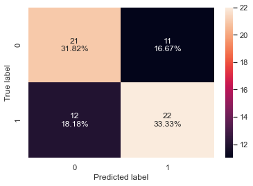

```python
confusion_matrix_sklearn(dtree_estimator, X_train, y_train)
```

```python
dtree_estimator_model_train_perf = model_performance_classification_sklearn(
    dtree_estimator, X_train, y_train
)
dtree_estimator_model_train_perf
```

|  | Accuracy | Recall | Precision | F1 |
| --- | --- | --- | --- | --- |
| 0 | 0.651515 | 0.647059 | 0.666667 | 0.656716 |

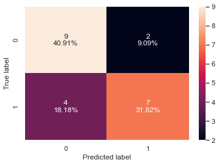

```python
confusion_matrix_sklearn(dtree_estimator, X_test, y_test)
```

```python
dtree_estimator_model_test_perf = model_performance_classification_sklearn(
    dtree_estimator, X_test, y_test
)
dtree_estimator_model_test_perf
```

|  | Accuracy | Recall | Precision | F1 |
| --- | --- | --- | --- | --- |
| 0 | 0.727273 | 0.636364 | 0.777778 | 0.7 |

- The decision tree model has a high precision but, the recall is quite less.
- The performance of the model after hyperparameter tuning has become generalized.
- We are getting an F1 score of 0.65 and 0.7 on the training and test set, respectively.
- Let's try building some ensemble models and see if the metrics improve.